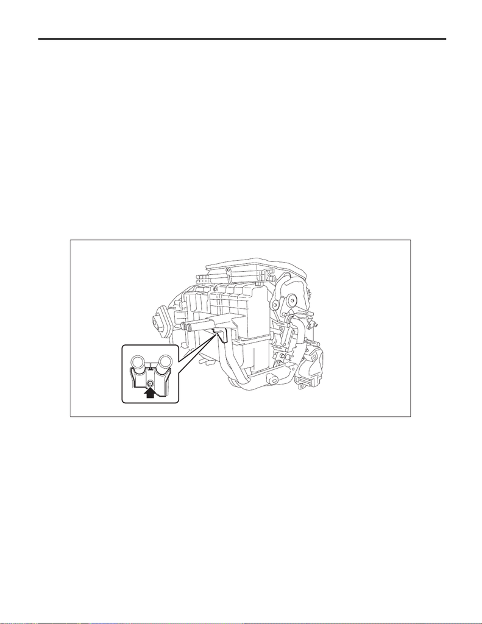

AC-40

Heater Core

HVAC SYSTEM (HEATER, VENTILATOR AND A/C)

12.Heater Core

A: REMOVAL

CAUTION:

Before handling the airbag module, refer to “CAUTION” of “General Description” in “AIRBAG SYS-

TEM”. <Ref. to AB-9, CAUTION, General Description.>

1) Using the refrigerant recovery system, discharge refrigerant. <Ref. to AC-26, PROCEDURE, Refrigerant

Recovery Procedure.>

2) Disconnect the battery ground cable and wait for at least 60 seconds before starting work. <Ref. to NT-5,

BATTERY, NOTE, Note.>

NOTE:

For models other than STI model, disconnect the ground terminal from battery sensor.

3) Drain engine coolant.

• Except for STI model: <Ref. to CO(w/o STI)-13, DRAINING OF ENGINE COOLANT, REPLACEMENT,

Engine Coolant.>

• STI model: <Ref. to CO(STI)-13, DRAINING OF ENGINE COOLANT, REPLACEMENT, Engine Coolant.>

4) Remove the heater and cooling unit assembly. <Ref. to AC-54, REMOVAL, Heater and Cooling Unit.>

5) Remove the heater core.

(1) Remove the screw and detach the clamp - pipe.

AC-02687

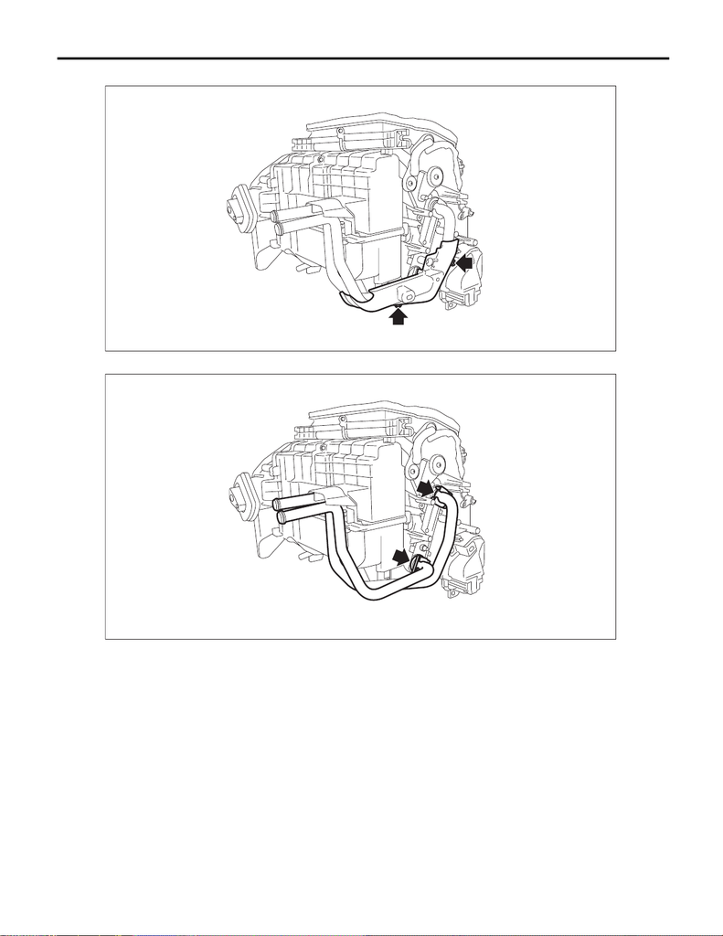

AC-41

Heater Core

HVAC SYSTEM (HEATER, VENTILATOR AND A/C)

(2) Remove the screws and detach the cover - heater pipe.

(3) Remove the clamp, and remove the pipe - inlet and outlet.

AC-02688

AC-02689

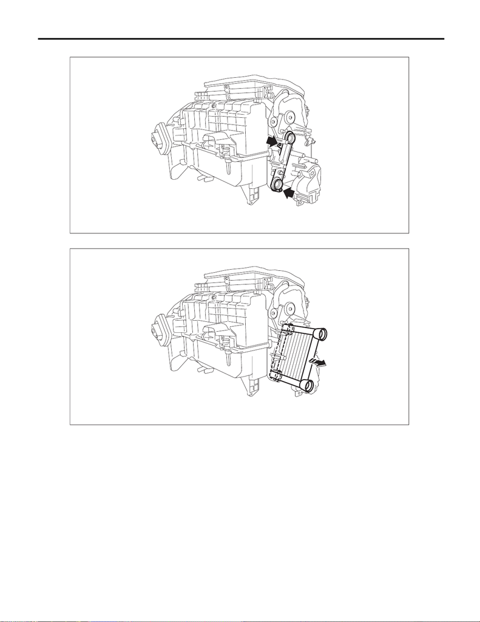

AC-42

Heater Core

HVAC SYSTEM (HEATER, VENTILATOR AND A/C)

(4) Remove the screws and detach the plate - heater core.

(5) Remove the heater core.

AC-02690

AC-02691

[figure not shown]

AC-43

Heater Core

HVAC SYSTEM (HEATER, VENTILATOR AND A/C)

B: INSTALLATION

CAUTION:

Before handling the airbag module, refer to “CAUTION” of “General Description” in “AIRBAG SYS-

TEM”. <Ref. to AB-9, CAUTION, General Description.>

CAUTION:

• Replace O-rings and clamps with new parts and install securely.

• Before handling the airbag module, refer to “CAUTION” of “General Description” in “AIRBAG SYS-

TEM”. <Ref. to AB-9, CAUTION, General Description.>

1) Attach the heater core.

2) Install the heater and cooling unit assembly. <Ref. to AC-56, INSTALLATION, Heater and Cooling Unit.>

3) Connect the battery ground terminal. <Ref. to NT-5, BATTERY, NOTE, Note.>

NOTE:

For models other than STI model, connect the ground terminal to battery sensor.

4) Fill engine coolant.

• Except for STI model: <Ref. to CO(w/o STI)-14, FILLING OF ENGINE COOLANT, REPLACEMENT, En-

gine Coolant.>

• STI model: <Ref. to CO(STI)-13, FILLING OF ENGINE COOLANT, REPLACEMENT, Engine Coolant.>

5) Charge refrigerant. <Ref. to AC-27, PROCEDURE, Refrigerant Charging Procedure.>